# ClimateTR package for temporal aggregation and trend analysis of climate data

## Introduction

This package is proposed as a solution to perform temporal aggregation of raster time series climate data by automatically generating indices for aggregation and grouping the layers according to the indices and then perform the aggregation. The aggregations can be specified either by days,monthly, annual and season. The package also provides solution for performing trend analysis of raster time series climate data. Two methods of trend analysis are made available one parametric method that is the linear regression and one non parametric method that is modified Mann Kendall test.

To illustrate how the package works first step is loading the package

```r
library(climateTR)
library(terra)
library(rasterVis)
library(RColorBrewer)
```

The required package is climateTR and terra. The rasterVis and RColorBrewer package are used here as means to visualize results.

## Data Description

Two datasets are used to demonstrate the capabilities of the package One is rainfall time series raster data from [CHIRPS](https://www.chc.ucsb.edu/data/chirps) at 5km spatial resolution of the year 2019 and Monthly rainfall data from [Climatology lab(TerraClimate)](https://www.climatologylab.org/terraclimate.html) at 4km spatial resolution from the year 1988 to 2018 for Kilosa district.

## Data Analysis and results

### Aggregation of raster time series climate data

#### Aggregating from daily data to days aggregation

For this example we aggregate from Kilosa daily rainfall data of year 2019 from [CHIRPS](https://www.chc.ucsb.edu/data/chirps) and we aggregate to 5 days rainfall amounts. We first add the data

```r
daily <- rast(system.file("/daily/kilosa_rainDaily.tif",package = "climateTR"))
daily
```

```
#> class       : SpatRaster
#> dimensions  : 36, 20, 365  (nrow, ncol, nlyr)
#> resolution  : 0.05, 0.05  (x, y)
#> extent      : 36.5, 37.5, -7.850001, -6.050001  (xmin, xmax, ymin, ymax)
#> coord. ref. : lon/lat WGS 84 (EPSG:4326)
#> source      : kilosa_rainDaily.tif
#> names       : chirp~01.01, chirp~01.02, chirp~01.03, chirp~01.04, chirp~01.05, chirp~01.06, ...
#> min values  :           0,      0.0000,    0.000000,     0.00000,           0,           0, ...
#> max values  :           0,     15.9846,    9.927839,    11.24057,           0,           0, ...
```

We then use the aggr() function specifying the raster data,aggregation type, aggregation days,current temporal resolution, start date, end date and function to be applied.

```r
five_agg<- aggr(daily,agg_type ="days",agg_days =5,temp ="day",start = "2019-01-01",end = "2019-12-31",func = sum)
five_agg
```

```
#> class       : SpatRaster
#> dimensions  : 36, 20, 73  (nrow, ncol, nlyr)
#> resolution  : 0.05, 0.05  (x, y)
#> extent      : 36.5, 37.5, -7.850001, -6.050001  (xmin, xmax, ymin, ymax)
#> coord. ref. : lon/lat WGS 84 (EPSG:4326)
#> source(s)   : memory
#> names       :      X1,      X2,       X3,        X4,       X5,       X6, ...
#> min values  :  0.0000,  0.0000,  0.00000,  36.00288,  0.00000,  0.00000, ...
#> max values  : 15.9846, 23.2468, 33.45634, 111.88248, 34.99809, 10.48563, ...
```

We obtain a SpatRaster of 73 layers from 365 because we move from daily to 5 days rainfall data.

#### Aggregation of daily data to monthly

We have seen a temporal aggregation of daily rainfall to 5 days rainfall aggregation of the year 2019 now we aggregate to monthly rainfall data from the daily data. We use aggr() function and specify the aggregation type(agg_type) to “monthly” ,exclude the agg_days parameter and the rest of parameters as for “days” aggregation are maintained

```r
monthly_agg<-aggr(daily,agg_type ="monthly",temp ="day",start = "2019-01-01",end = "2019-12-31",func = sum)
monthly_agg
```

```
#> class       : SpatRaster
#> dimensions  : 36, 20, 12  (nrow, ncol, nlyr)
#> resolution  : 0.05, 0.05  (x, y)
#> extent      : 36.5, 37.5, -7.850001, -6.050001  (xmin, xmax, ymin, ymax)
#> coord. ref. : lon/lat WGS 84 (EPSG:4326)
#> source(s)   : memory
#> names       :    X20191,    X20192,    X20193,    X20194,     X20195,   X20196, ...
#> min values  :  70.43102,  98.16862,  87.44903,  55.64105,   6.603684,  0.00000, ...
#> max values  : 175.76815, 246.85190, 331.71989, 630.70143, 243.345219, 29.08525, ...
```

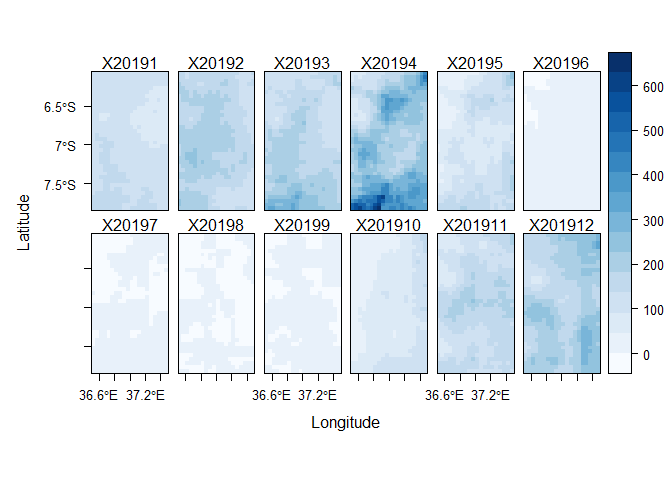

```r
blues <- brewer.pal('Blues', n = 9)
myTheme.blues <- rasterTheme(region = c( blues))

levelplot(monthly_agg,par.settings=myTheme.blues,margin=FALSE)
```

From the aggregation it can be observed that now we have 12 layers in our SpatRaster and the from the names we can observe that the year and month of each layer is indicated along with the prefix “x”.We visualize results using levelplot() function of the ‘rasterVis’ package.

#### Aggregation of monthly climate data to annual

This package has the capability of also aggregating monthly data to annual data. For this example we use monthly rainfall climate data of Kilosa of year 1988 to 2018 from the [Climatology lab(TerraClimate)](https://www.climatologylab.org/terraclimate.html).The first step is load the dataset

```r
monthly <- rast(system.file("/monthly/kilosa_rainMonthly.tif",package = "climateTR"))
monthly
```

```
#> class       : SpatRaster
#> dimensions  : 44, 24, 372  (nrow, ncol, nlyr)
#> resolution  : 0.0416318, 0.0416318  (x, y)
#> extent      : 36.48724, 37.4864, -7.869012, -6.037213  (xmin, xmax, ymin, ymax)
#> coord. ref. : lon/lat WGS 84 (EPSG:4326)
#> source      : kilosa_rainMonthly.tif
#> names       : ppt19~01-01, ppt19~02-01, ppt19~03-01, ppt19~04-01, ppt19~05-01, ppt19~06-01, ...
#> min values  :    123.4633,    66.97236,    135.0408,    61.48168,    11.24905,    15.57012, ...
#> max values  :    211.2785,   165.38570,    355.5273,   215.62131,    74.16124,    89.80997, ...
```

To aggregate to annual the aggr() function is used now specifying type of aggregation to “annual” , current temporal resolution to “month” ,start for start date that is 1988-01-01 and end for end date that is 2018-12-31

```r
annual_agg<- aggr(monthly,agg_type = "annual",temp = "month",start = "1988-01-01",end = "2018-12-31",func = sum)
names(annual_agg)<-paste0('y',1988:2018)
annual_agg
```

```
#> class       : SpatRaster
#> dimensions  : 44, 24, 31  (nrow, ncol, nlyr)
#> resolution  : 0.0416318, 0.0416318  (x, y)
#> extent      : 36.48724, 37.4864, -7.869012, -6.037213  (xmin, xmax, ymin, ymax)
#> coord. ref. : lon/lat WGS 84 (EPSG:4326)
#> source(s)   : memory
#> names       :     y1988,     y1989,     y1990,     y1991,     y1992,    y1993, ...
#> min values  :  556.5045,  649.4419,  589.5755,  607.3737,  487.0735,  463.539, ...
#> max values  : 1424.9091, 1839.2406, 1467.7619, 1620.9631, 1356.6929, 1283.909, ...
```

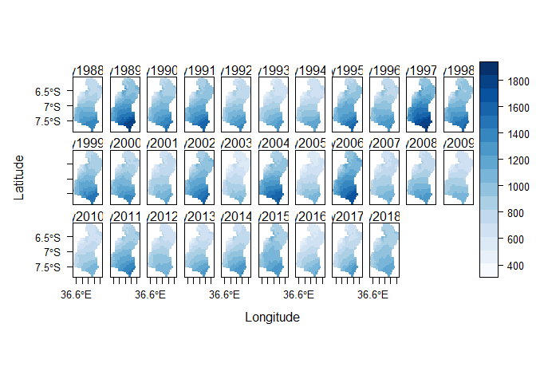

```r
blues <- brewer.pal('Blues', n = 9)
myTheme.blues <- rasterTheme(region = c( blues))

levelplot(annual_agg,par.settings=myTheme.blues,margin=FALSE)
```

From the aggregation from 372 monthly layers now there are 31 annual layers equivalent to the number of years from 1988 to 2018

#### Aggregation of monthly climate data to season

The aggr() function also has the capability of conducting season aggregation example JFM(January,February,March) by providing a vector of numerical values according to the month in the agg_month parameter and changing agg_type to “season”.It also has the capability of aggregating overlapping seasons between one year and another.The first illustration is for seasons with in same years.First for OND(October, November, December) season.

```r
OND_agg<- aggr(monthly,agg_type = "season",agg_month =c(10,11,12),temp = "month",start = "1988-01-01",end = "2018-12-31",func = sum)
OND_agg
```

```
#> class       : SpatRaster
#> dimensions  : 44, 24, 31  (nrow, ncol, nlyr)
#> resolution  : 0.0416318, 0.0416318  (x, y)
#> extent      : 36.48724, 37.4864, -7.869012, -6.037213  (xmin, xmax, ymin, ymax)
#> coord. ref. : lon/lat WGS 84 (EPSG:4326)
#> source(s)   : memory
#> names       :       X1,       X2,        X3,       X4,       X5,        X6, ...
#> min values  : 135.4303, 192.2152,  88.82379, 185.1168, 142.7599,  47.45965, ...
#> max values  : 351.7926, 541.8916, 304.17232, 470.6158, 386.1335, 142.72912, ...
```

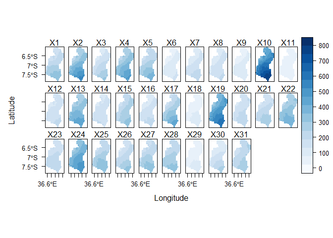

```r
blues <- brewer.pal('Blues', n = 9)
myTheme.blues <- rasterTheme(region = c( blues))

levelplot(OND_agg,par.settings=myTheme.blues,margin=FALSE)
```

From the results we obtain 31 layers from 372 layers similar to monthly to annual aggregation but this time only for months October November and December.

Now for overlapping season example from October to April of the next year can be done as follows.

```r
OToA_agg<-aggr(monthly,agg_type = "season",temp = "month",agg_month = c(10,11,12,1,2,3,4),start = "1988-01-01",end = "2018-12-31",func = sum)
OToA_agg
```

```
#> class       : SpatRaster
#> dimensions  : 44, 24, 30  (nrow, ncol, nlyr)
#> resolution  : 0.0416318, 0.0416318  (x, y)
#> extent      : 36.48724, 37.4864, -7.869012, -6.037213  (xmin, xmax, ymin, ymax)
#> coord. ref. : lon/lat WGS 84 (EPSG:4326)
#> source(s)   : memory
#> names       :        X1,        X2,        X3,        X4,        X5,       X6, ...
#> min values  :  535.9017,  677.3872,  476.7697,  494.7583,  543.6496,  446.480, ...
#> max values  : 1361.4572, 1570.2570, 1228.6406, 1235.5249, 1401.8042, 1019.192, ...
```

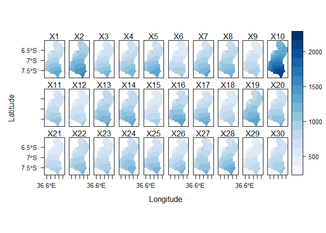

```r
blues <- brewer.pal('Blues', n = 9)
myTheme.blues <- rasterTheme(region = c( blues))

levelplot(OToA_agg,par.settings=myTheme.blues,margin=FALSE)
```

For overlapping seasons aggregation we end up with only 30 layers because season span from one year to the next therefore from the 31 years data we have only 30 seasons.

### Trend analysis of climate data

This section illustrate how the climateTR package conducts trend analysis based on linear regression method that is a parametric method and modified Mann Kendall method that is a non parametric method

#### Using Linear regression

For the linear regression the function trend_rast() is used where the user can add the SpatRaster containing several layers and choose the method to apply by specifying the method parameter in this case “regression”. The annual data is used in the illustration

```r
reg_trend<- trend_rast(annual_agg,method = "regression")
```

[output not shown]

```r
reg_trend
```

```
#> class       : SpatRaster
#> dimensions  : 44, 24, 2  (nrow, ncol, nlyr)
#> resolution  : 0.0416318, 0.0416318  (x, y)
#> extent      : 36.48724, 37.4864, -7.869012, -6.037213  (xmin, xmax, ymin, ymax)
#> coord. ref. : lon/lat WGS 84 (EPSG:4326)
#> source(s)   : memory
#> names       :      slope,      pvalue
#> min values  : -12.024589, 0.002090293
#> max values  :  -3.239258, 0.155258106
```

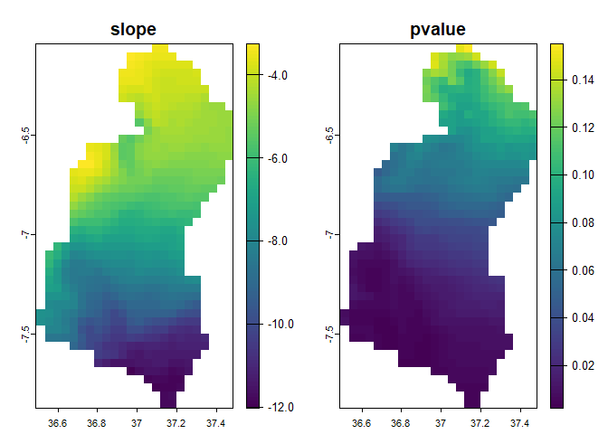

```r
plot(reg_trend)
```

From the results we see that two layers are obtained one showing the changes(slope) where positive values mean increase and negative values describe a decrease and another containing the pvalues which can be used to identify where changes are significant

#### Using Mann Kendall

Using the Mann Kendall only the method is changed to “Mann_Kendall”

```r
mann_trend<-trend_rast(annual_agg,method = "Mann_Kendall")
```

[output not shown]

```r
mann_trend
```

```
#> class       : SpatRaster
#> dimensions  : 44, 24, 2  (nrow, ncol, nlyr)
#> resolution  : 0.0416318, 0.0416318  (x, y)
#> extent      : 36.48724, 37.4864, -7.869012, -6.037213  (xmin, xmax, ymin, ymax)
#> coord. ref. : lon/lat WGS 84 (EPSG:4326)
#> source(s)   : memory
#> names       : Sens_slope,        pvalue
#> min values  : -11.645337, 0.00002231656
#> max values  :  -3.386087, 0.15337850689
```

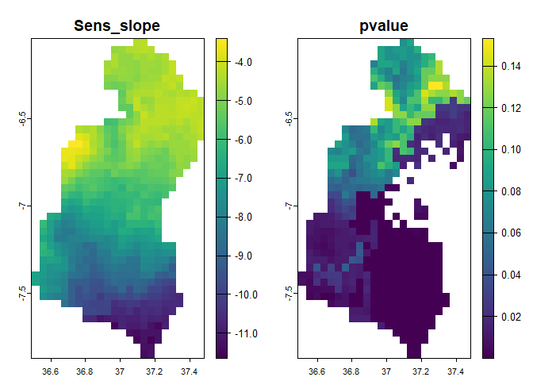

```r
plot(mann_trend)
```

From Mann Kendall the outcome is Sens_slope indicating the changes over period of 1988 to 2018 where positive values mean increase and negative values describe a decrease and pvalue describes the significance of the changes